# Risk Prediction of Default on Rent Payments

```python
#required imports
import numpy as np
import pandas as pd
```

```python
#loading the data
dataset = pd.read_excel("https://archive.ics.uci.edu/ml/machine-learning-databases/00350/default%20of%20credit%20card%20clients.xls")
dataset.columns = dataset.iloc[0]
```

```python
# dataset.drop(['ID'], axis = 1, inplace=True)
dataset=dataset[1:]
dataset.head(10)
```

|  | LIMIT_BAL | SEX | EDUCATION | MARRIAGE | AGE | PAY_0 | PAY_2 | PAY_3 | PAY_4 | PAY_5 | ... | BILL_AMT4 | BILL_AMT5 | BILL_AMT6 | PAY_AMT1 | PAY_AMT2 | PAY_AMT3 | PAY_AMT4 | PAY_AMT5 | PAY_AMT6 | default payment next month |
| --- | --- | --- | --- | --- | --- | --- | --- | --- | --- | --- | --- | --- | --- | --- | --- | --- | --- | --- | --- | --- | --- |
| 1 | 20000 | 2 | 2 | 1 | 24 | 2 | 2 | -1 | -1 | -2 | ... | 0 | 0 | 0 | 0 | 689 | 0 | 0 | 0 | 0 | 1 |
| 2 | 120000 | 2 | 2 | 2 | 26 | -1 | 2 | 0 | 0 | 0 | ... | 3272 | 3455 | 3261 | 0 | 1000 | 1000 | 1000 | 0 | 2000 | 1 |
| 3 | 90000 | 2 | 2 | 2 | 34 | 0 | 0 | 0 | 0 | 0 | ... | 14331 | 14948 | 15549 | 1518 | 1500 | 1000 | 1000 | 1000 | 5000 | 0 |
| 4 | 50000 | 2 | 2 | 1 | 37 | 0 | 0 | 0 | 0 | 0 | ... | 28314 | 28959 | 29547 | 2000 | 2019 | 1200 | 1100 | 1069 | 1000 | 0 |
| 5 | 50000 | 1 | 2 | 1 | 57 | -1 | 0 | -1 | 0 | 0 | ... | 20940 | 19146 | 19131 | 2000 | 36681 | 10000 | 9000 | 689 | 679 | 0 |
| 6 | 50000 | 1 | 1 | 2 | 37 | 0 | 0 | 0 | 0 | 0 | ... | 19394 | 19619 | 20024 | 2500 | 1815 | 657 | 1000 | 1000 | 800 | 0 |
| 7 | 500000 | 1 | 1 | 2 | 29 | 0 | 0 | 0 | 0 | 0 | ... | 542653 | 483003 | 473944 | 55000 | 40000 | 38000 | 20239 | 13750 | 13770 | 0 |
| 8 | 100000 | 2 | 2 | 2 | 23 | 0 | -1 | -1 | 0 | 0 | ... | 221 | -159 | 567 | 380 | 601 | 0 | 581 | 1687 | 1542 | 0 |
| 9 | 140000 | 2 | 3 | 1 | 28 | 0 | 0 | 2 | 0 | 0 | ... | 12211 | 11793 | 3719 | 3329 | 0 | 432 | 1000 | 1000 | 1000 | 0 |
| 10 | 20000 | 1 | 3 | 2 | 35 | -2 | -2 | -2 | -2 | -1 | ... | 0 | 13007 | 13912 | 0 | 0 | 0 | 13007 | 1122 | 0 | 0 |

10 rows × 24 columns

## Decision tree and Confusion Matrix

```python
import numpy as np
import matplotlib.pyplot as plt
from scipy import stats
from sklearn.tree import DecisionTreeClassifier
from sklearn import tree
```

```python
y = dataset['default payment next month'].copy()
y = y.astype('int')

features = ['LIMIT_BAL', 'SEX', 'EDUCATION', 'MARRIAGE', 'AGE', 'PAY_0', 'PAY_2',
       'PAY_3', 'PAY_4', 'PAY_5', 'PAY_6', 'BILL_AMT1', 'BILL_AMT2',
       'BILL_AMT3', 'BILL_AMT4', 'BILL_AMT5', 'BILL_AMT6', 'PAY_AMT1',
       'PAY_AMT2', 'PAY_AMT3', 'PAY_AMT4', 'PAY_AMT5', 'PAY_AMT6']
X = dataset[features].copy()
X.columns
```

```
Index(['LIMIT_BAL', 'SEX', 'EDUCATION', 'MARRIAGE', 'AGE', 'PAY_0', 'PAY_2',
       'PAY_3', 'PAY_4', 'PAY_5', 'PAY_6', 'BILL_AMT1', 'BILL_AMT2',
       'BILL_AMT3', 'BILL_AMT4', 'BILL_AMT5', 'BILL_AMT6', 'PAY_AMT1',
       'PAY_AMT2', 'PAY_AMT3', 'PAY_AMT4', 'PAY_AMT5', 'PAY_AMT6'],
      dtype='object', name=0)
```

```python
from sklearn.ensemble import AdaBoostClassifier
from sklearn.model_selection import train_test_split
from sklearn.metrics import accuracy_score
X_train, X_test, y_train, y_test = train_test_split(X, y, test_size = 0.3, random_state=123)
```

```python
from sklearn.tree import DecisionTreeClassifier
decision_tree = DecisionTreeClassifier(max_depth = 5, max_leaf_nodes=5, random_state = 123)
```

```python
decision_tree.fit(X_train, y_train)
predict = decision_tree.predict(X_test)
```

```
Accuracy of the Decison Tree test is:  82.24 %
```

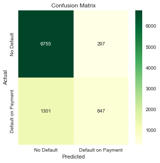

```python
from sklearn.metrics import confusion_matrix
import seaborn as sns
cm = pd.crosstab(y_test, predict, rownames=['Actual'], colnames=['Predicted'])
fig, (ax1) = plt.subplots(figsize=(5,5))
sns.heatmap(cm,
            xticklabels=['No Default', 'Default on Payment'],
            yticklabels=['No Default', 'Default on Payment'],
            annot=True, ax=ax1,
             cmap="YlGn", fmt="d" )
plt.title('Confusion Matrix')
print("Accuracy of the Decison Tree test is: ",round(accuracy_score(y_test, predict)*100,2),"%")
plt.show()
```

```python
decision_tree = DecisionTreeClassifier(max_depth = 25, random_state = 123)
```

```python
decision_tree.fit(X_train, y_train)
predict = decision_tree.predict(X_test)
```

```
Accuracy of the Decison Tree test is:  74.07 %
```

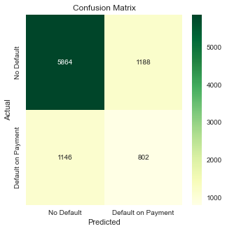

```python
from sklearn.metrics import confusion_matrix
import seaborn as sns
cm = pd.crosstab(y_test, predict, rownames=['Actual'], colnames=['Predicted'])
fig, (ax1) = plt.subplots(figsize=(5,5))
sns.heatmap(cm,
            xticklabels=['No Default', 'Default on Payment'],
            yticklabels=['No Default', 'Default on Payment'],
            annot=True, ax=ax1,
             cmap="YlGn", fmt="d" )
plt.title('Confusion Matrix')
print("Accuracy of the Decison Tree test is: ",round(accuracy_score(y_test, predict)*100,2),"%")
plt.show()
```

Under first Confusion Matrix I have limited the maximum amount of leafs and depth of our Decision Tree Classifier. Having a limited amount of depth allowed us to increase our accuracy as limited amount of depth prevents our model to be overfitted. In my second test I have decided to allow our Decision Tree to grow tall with a max depth of 25, and no limit to the number of leafs. This in turn have overfitted our model and substantially decreased the accuracy of our model by roughly **8%**.

#### RandomizedSearchCV

```python
# YOUR CODE HERE
from sklearn.model_selection import RandomizedSearchCV
```

```python
param_grid = {'max_depth': [3,4,5,6,7,8,9,10,15],
             'criterion' : ['gini','entropy'],
             'max_leaf_nodes': [3,5,10,20,100],
             'min_samples_split': [2, 5, 10, 20]}
```

```python
grid_search = RandomizedSearchCV(DecisionTreeClassifier(), param_grid, scoring='accuracy')
```

```python
grid_search.fit(X_train, y_train)
print(grid_search.best_estimator_)
print(f'Accuracy score under RandomizedSearch of potential hyper-parameters is {round((grid_search.best_score_)*100,2)} %')
```

```
DecisionTreeClassifier(criterion='entropy', max_depth=8, max_leaf_nodes=20,
                       min_samples_split=5)
Accuracy score under RandomizedSearch of potential hyper-parameters is 82.02 %
```

```python
decision_tree = DecisionTreeClassifier(criterion='entropy', max_depth=4, max_leaf_nodes=100,
                       min_samples_split=10, random_state = 123)
```

```python
X_train, X_test, y_train, y_test = train_test_split(X, y, test_size = 0.3, random_state=123)
```

```python
decision_tree.fit(X_train, y_train)
predict = decision_tree.predict(X_test)
```

```
Accuracy of the Decison Tree test is:  82.2 %
```

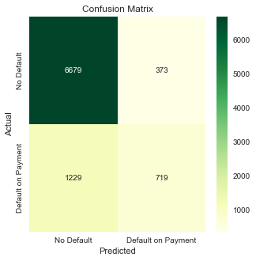

```python
cm = pd.crosstab(y_test, predict, rownames=['Actual'], colnames=['Predicted'])
fig, (ax1) = plt.subplots(figsize=(5,5))
sns.heatmap(cm,
            xticklabels=['No Default', 'Default on Payment'],
            yticklabels=['No Default', 'Default on Payment'],
            annot=True, ax=ax1,
             cmap="YlGn", fmt="d" )
plt.title('Confusion Matrix')
print("Accuracy of the Decison Tree test is: ",round(accuracy_score(y_test, predict)*100,2),"%")
plt.show()
```

- Random Forest
- AdaBoost
- Extra Trees Classifier
- Gradient Boosted Trees

```python
from sklearn.ensemble import RandomForestClassifier
from sklearn.model_selection import learning_curve
import matplotlib.pyplot as plt
rfc = RandomForestClassifier()
rfc.fit(X_train, y_train)
rfc_predict = rfc.predict(X_test)
print("Random Forest Classifier Test Accuracy: ",round(accuracy_score(y_test,rfc_predict)*100,2),"%")
```

```
Random Forest Classifier Test Accuracy:  81.51 %
```

```python
train_sizes, train_scores, test_scores = learning_curve(RandomForestClassifier(), X, y, cv=5,
                                                        scoring='accuracy', n_jobs=-1)
```

```python
train_mean = np.mean(train_scores, axis=1)
train_std = np.std(train_scores, axis=1)

test_mean = np.mean(test_scores, axis=1)
test_std = np.std(test_scores, axis=1)
```

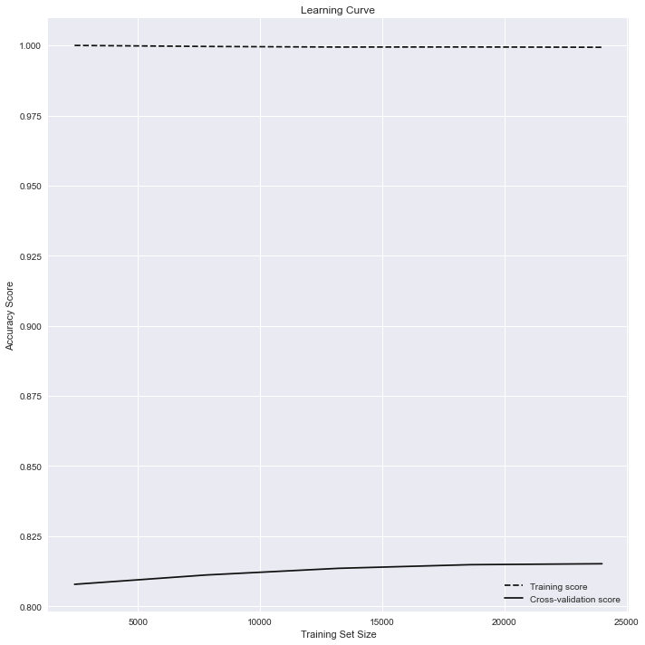

```python
plt.subplots(1, figsize=(10,10))
plt.plot(train_sizes, train_mean, '--', color="#111111",  label="Training score")
plt.plot(train_sizes, test_mean, color="#111111", label="Cross-validation score")

plt.title("Learning Curve")
plt.xlabel("Training Set Size"), plt.ylabel("Accuracy Score"), plt.legend(loc="best")
plt.tight_layout()
plt.show()
```

```python
from sklearn.ensemble import GradientBoostingClassifier
gbc = GradientBoostingClassifier()
gbc.fit(X_train, y_train)
gbc_predict = gbc.predict(X_test)
print("Gradient Boosting Classifier Test Accuracy: ",round(accuracy_score(y_test,gbc_predict)*100,2),"%")
```

```
Gradient Boosting Classifier Test Accuracy:  82.03 %
```

```python
from sklearn.ensemble import AdaBoostClassifier
abc = AdaBoostClassifier()
abc.fit(X_train, y_train)
abc_predict = abc.predict(X_test)
print("Ada Boost Classifier Test Accuracy: ",round(accuracy_score(y_test, abc_predict)*100,2),"%")
```

```
Ada Boost Classifier Test Accuracy:  81.88 %
```

```python
from sklearn.ensemble import ExtraTreesClassifier
etc = ExtraTreesClassifier()
etc.fit(X_train, y_train)
etc_predict = etc.predict(X_test)
print("Extra Trees Classifier Test Accuracy: ",round(accuracy_score(y_test,etc_predict)*100,2),"%")
```

```
Extra Trees Classifier Test Accuracy:  81.03 %
```

```python
train_sizes, train_scores, test_scores = learning_curve(etc, X, y, cv=5,
                                                        scoring='accuracy', n_jobs=-1)
```

```python
train_mean = np.mean(train_scores, axis=1)
train_std = np.std(train_scores, axis=1)

test_mean = np.mean(test_scores, axis=1)
test_std = np.std(test_scores, axis=1)
```

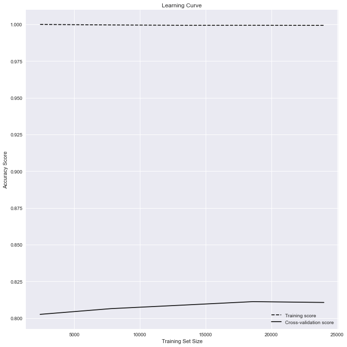

```python
plt.subplots(1, figsize=(10,10))
plt.plot(train_sizes, train_mean, '--', color="#111111",  label="Training score")
plt.plot(train_sizes, test_mean, color="#111111", label="Cross-validation score")


plt.title("Learning Curve")
plt.xlabel("Training Set Size"), plt.ylabel("Accuracy Score"), plt.legend(loc="best")
plt.tight_layout()
plt.show()
```

As we could see in the previous learning curve the number of data items increases accuracy of our learning curve. All of the models have a similar accuracy rate however degree to which their accuracy changes due to larger training set size is different. Our previous example had a steadily rising learning slope which would benefit from more data items however the Extra Trees Classifier stops benefiting from a larger training set size after roughly 18,000 items.

**How does changing hyperparms effect model performance?**

Hyperparms allow us to adjust the model to have the most effective accuracy, without overfitting the model. Grid Search and Param Search are instrumental in us achievinig the most reliable combination of parameters without guesswok involved.

**Why do you think certain models performed better/worse?**

Some models are fit better or worse for different types of data sets. For example some data with binary attributes might be less fit for a classifier that excels in predicting floating-point number.

**How does this performance line up with known strengths/weakness of these models?**